# Project 1

## DAB501 - Project #1 – Problem Statement

### Team Introduction

Group #11

Section #04

Team Members: Aesha Rathod || Gurjinderpal Singh || Tehsin Shaikh

### Background

Supermarkets play a crucial role in our daily lives by providing us with the necessary groceries and household items. The retail industry is constantly evolving with changing consumer demands, technological advancements, and economic fluctuations. Therefore, it is imperative for supermarkets to optimize their operations to stay competitive, improve customer satisfaction, and maximize profits.

### Problem statement

1.To analyze the supermarket’s sales and order management data to identify customers buying patterns and trends.

2. To analyze supermarket’s 1) Most popular meal 2) Sales trends 4) Order management. It can help identify which products are in high demand, which products are slow-moving, which products are not selling at all and delivery time to serve the orders. This analysis can be used to optimize the supermarket’s order management, pricing strategy, and marketing campaigns.

### Project Proposal

We will create a descriptive model to identify trends and patterns in customer behavior and product sales. This will help the store better understand their customers and optimize their orders, pricing, and marketing strategies to improve sales and customer satisfaction.

### Analysis Questions

1. What are the top-selling products and how does their sales volume and revenue compare?

2. What are the busiest days and times for each store, and how can the supermarket chain optimize their delivery time to meet demand?

3. Are there any product categories that are consistently underperforming, and how can the supermarket chain address this issue?

4. Can the supermarket chain identify any patterns in customer behavior, such as recurring purchases or differences in purchasing behavior across different customer segments?

5. How effective are the store’s pricing strategies, and are there opportunities to improve margins or offer more competitive prices?

### Academic Integrity

Integrity means to make choices according to a certain set of values.

Academic integrity means to be guided by shared values and norms of behaviour in all aspects of one’s academic work.

St. Clair College is committed to the six fundamental values of academic integrity: honesty, trust, fairness, respect, responsibility, and courage. Applying these values can help guide students to make good choices about how to approach their schoolwork. Academic integrity means putting those values into practice and being accountable.

Faculty, staff and students each play an important role in building and maintaining a culture of academic integrity. All members of our college community have a shared responsibility to uphold the principles of academic integrity so that the teaching-learning relationship is built on mutual trust and respect, and that we maintain an honest and fair learning environment.

Academic integrity is integral to a student’s academic success. The habits that students develop on their academic journey while at St. Clair College will carry them not only through their program of study but also into the workplace.

### **Version**

**R** - R version 4.2.2 (2022-10-31)

**R Studio** - RStudio 2022.12.0 Build 353

**R packages**: base : 4.2.2 datasets : 4.2.2 ggplot2 3.4.0 graphics 4.2.2 grDevices 4.2.2 methods 4.2.2 purrr 1.0.1 readr 2.1.3 stats 4.2.2 stringr 1.5.0 tibble 3.1.8 tidyverse 1.3.2 utils 4.2.2

**Documentation of Data sets**:

Owner of data - Sathish Pichika

Link to dataset - https://drive.google.com/drive/folders/1tjkmw5Od15DX8IIDgOlKdIz9DXYfsXAh

### **Dataset Summary Information**

This data set provides an in-depth look into the ordering, invoicing and sales processes at a supermarket. With information ranging from customers’ meal choices to the value of their orders and whether they were converted into sales, this dataset opens up endless possibilities to uncover consumer behavior trends and engagement within the business. From understanding who is exchanging with the company and when, to seeing what types of meals are most popular with consumers, this rich collection of data will allow us to gain priceless insights into consumer actions and habits that can inform strategic decisions.

### **Dataset Modifications**

- Converted data in the column “Converted from numeric(0 & 1) to Categorical (0 ->”Not converted” , 1->“Converted”) in the dataFrame OrderLeads

```r
library(readxl)
OrderLeads <- read_xlsx("/Users/gurjinderpalsingh/Desktop/Gurjinder/Data Analytics for Business/DAB501 Rstudio/Project 1/Dataset/OrderLeads.xlsx")
```

```r
# Below code converts the numerical data in Conversion column to Categorical data
OrderLeads$Converted[OrderLeads$Converted == 0] <- "Not Converted"
OrderLeads$Converted[OrderLeads$Converted == 1] <- "Converted"
```

```r
library(readxl)
Invoices <- read_xlsx("/Users/gurjinderpalsingh/Desktop/Gurjinder/Data Analytics for Business/DAB501 Rstudio/Project 1/Dataset/Invoices.xlsx")
```

```r
# Converting Datatype of Date column in Invoices to 'Date'
Invoices$Date <- as.Date(Invoices$Date)
```

```r
datebreaks <- seq(as.Date("2014-01-01"), as.Date("2018-12-12"), by = "12 month")
datebreaks
```

```
## [1] "2014-01-01" "2015-01-01" "2016-01-01" "2017-01-01" "2018-01-01"
```

```r
library(ggplot2)
```

#### **#1 Plot showing Continuous Variable**

Overall, this code creates a visualization to explore the distribution of order placed in the dataset “Invoices”.

Plot 1

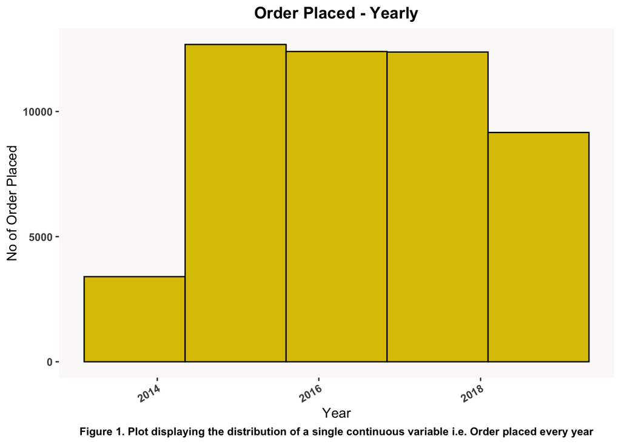

```r
ggplot(Invoices,aes(x=Date))+
  geom_histogram(fill='#DDC300',color='black',bins=5)+
  #scale_x_date(breaks = datebreaks) +
  theme(axis.text.x = element_text(angle = 30, hjust = 1)) +
  #geom_label(aes(label = after_stat(count)), stat = "count", hjust=0.5 )+
  labs(x="Year",
       y="No of Order Placed" ,
       title = "Order Placed - Yearly",
       caption = "Figure 1. Plot displaying the distribution of a single continuous variable i.e. Order placed every year") +
  theme(plot.title = element_text(hjust=0.5,face = "bold"))+
  theme(plot.caption = element_text(hjust = 0.5,face = "bold"),axis.text.x = element_text(face = "bold"),,axis.text.y = element_text(face = "bold"),panel.grid.major = element_blank(),panel.grid.minor = element_blank(),panel.background = element_rect(fill = "#FAF9F9"))
```

#### **#2 Plot showing Continuous Variable**

**Description**:This code is creating a histogram-like plot using ggplot, showing the frequency distribution of meal prices in a dataset called “Invoices”. The x-axis represents the meal price, and the y-axis represents the number of orders placed at that price.The geom_freqpoly() function specifies the type of plot to be drawn, which is a frequency polygon, and aes(x=MealPrice) maps the meal price variable to the x-axis.

Overall, this code creates a visualization to explore the distribution of meal prices in the dataset “Invoices”.

Plot 2

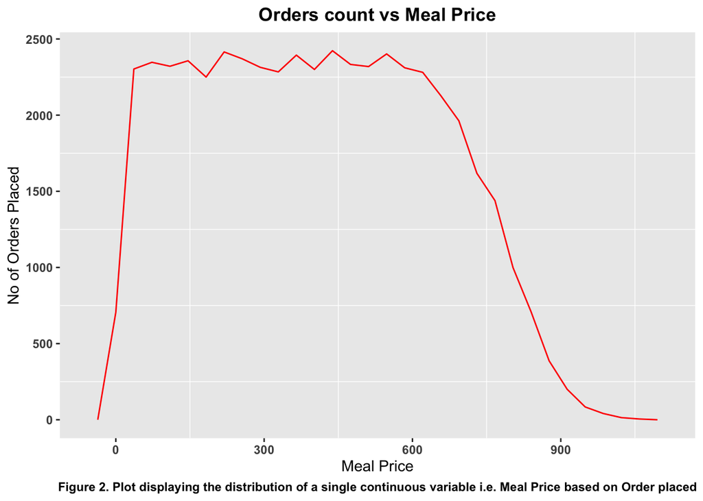

```r
ggplot(Invoices,aes(x=MealPrice))+
  geom_freqpoly(color="Red")+
  labs(x="Meal Price",
       y="No of Orders Placed" ,
       title = "Orders count vs Meal Price",
       caption = "Figure 2. Plot displaying the distribution of a single continuous variable i.e. Meal Price based on Order placed")+
  theme(plot.title = element_text(hjust=0.5,face = "bold"))+
  theme(plot.caption = element_text(hjust = 0.5,face = "bold"),axis.text.x = element_text(face = "bold"),,axis.text.y = element_text(face = "bold"),panel.grid.major = element_blank())
```

#### **#3 Plot showing Categorical Variable**

Overall, this code creates a simple visualization to explore the distribution of meal types in the “Invoices” dataset using a bar plot.

Plot 3

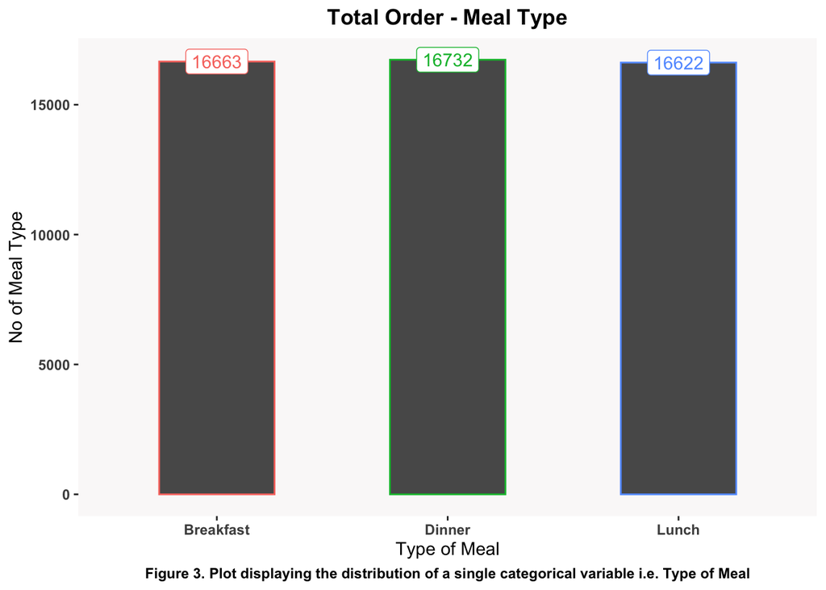

```r
# Meal type vs count
ggplot(Invoices,aes(x = MealType,color=MealType))+
 geom_bar(width = 0.5)+
 geom_label(aes(label = after_stat(count)), stat = "count" )+
    labs(x="Type of Meal", y="No of Meal Type" , title = "Total Order - Meal Type",
         caption = "Figure 3. Plot displaying the distribution of a single categorical variable i.e. Type of Meal")+
  theme(plot.title = element_text(hjust=0.5,face = "bold"))+
  theme(plot.caption = element_text(hjust=0.5,face = "bold"),axis.text.x = element_text(face = "bold"),,axis.text.y = element_text(face = "bold"),panel.grid.major = element_blank(),panel.grid.minor = element_blank(),panel.background = element_rect(fill = "#FAF9F9"))+
  guides(color=FALSE)
```

#### **#4 Plot showing Categorical Variable**

Plot 4

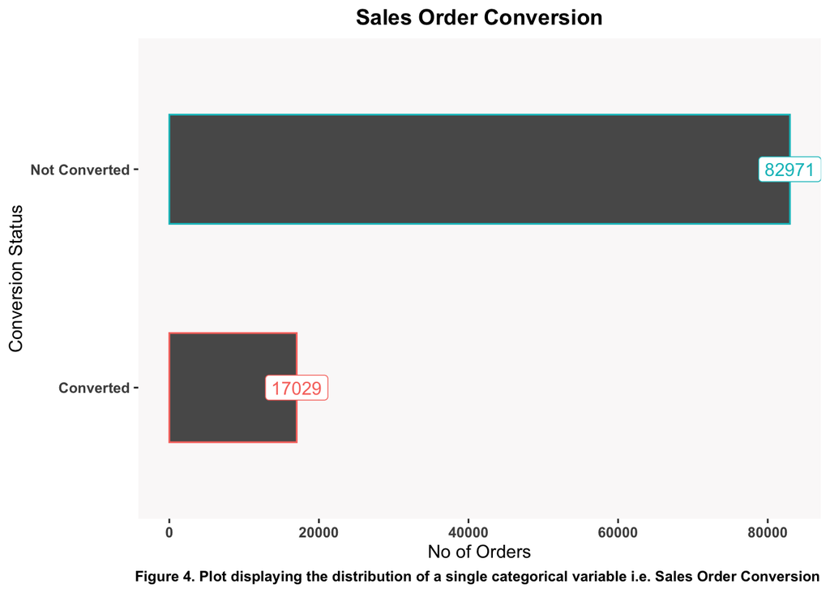

```r
ggplot(OrderLeads , aes(y=Converted,color=Converted))+
  geom_bar(width = 0.5)+
  geom_label(aes(label = after_stat(count)), stat = "count", hjust=0.5 )+
  labs(x="No of Orders", y="Conversion Status" , title = "Sales Order Conversion",
         caption = "Figure 4. Plot displaying the distribution of a single categorical variable i.e. Sales Order Conversion ")+
  theme(plot.title = element_text(hjust=0.5,face="bold"),plot.caption = element_text(hjust=0.5,face="bold"),axis.text.x = element_text(face = "bold"),,axis.text.y = element_text(face = "bold"),panel.grid.major = element_blank(),panel.grid.minor = element_blank(),panel.background = element_rect(fill = "#FAF9F9"))+
  guides(color=FALSE)
```

#### **#5 Plot showing both a Continuous Variable and a Categorical Variable**

**Description**:This code is creating a box plot using ggplot to visualize the distribution of meal prices for each meal type in a dataset called “Invoices”.The aes() function is used to map the MealType variable to the x-axis and the MealPrice variable to the y-axis of the plot.The geom_boxplot() function specifies the type of plot to be drawn, which is a box plot. The fill argument sets the color of the boxes to “slateblue”.

Overall, this code creates a simple visualization to explore the distribution of meal prices for each meal type in the “Invoices” dataset using a box plot. The box plot shows the median, interquartile range (IQR), and any outliers for each meal type. By comparing the box plots of different meal types, we can identify any differences in their distribution of meal prices.

Plot 5

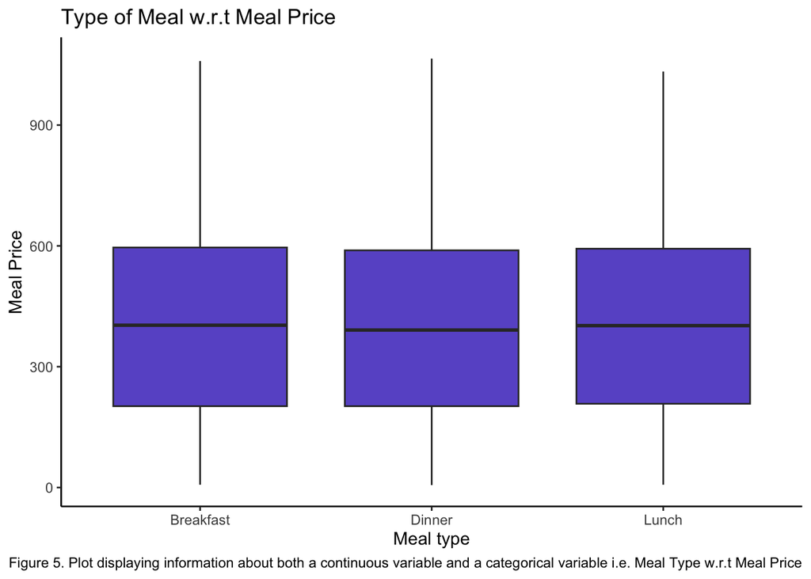

```r
ggplot(Invoices,aes(x=MealType,y=MealPrice))+
  geom_boxplot(fill ="slateblue")+
    labs(x="Meal type", y="Meal Price" , title = "Type of Meal w.r.t Meal Price",
         caption = "Figure 5. Plot displaying information about both a continuous variable and a categorical variable i.e. Meal Type w.r.t Meal Price")+
  theme(plot.title = element_text(hjust=0.5))+
  theme(plot.caption = element_text(hjust=0.3))+
  theme_classic()
```

#### **#6 Plot showing a relationship between two variables**

**Description**:The first block of code groups the “OrderLeads” dataset by CompanyName variable and calculates the total order value per company using summarise() function. Then, using filter() function, it filters the dataset to keep only the companies whose total order values are greater than 190,000.

The second block of code creates a column chart using ggplot to display the total order values for each of the top companies with order values greater than 190,000.The ggplot() function initializes an empty plot object. The geom_col() function is used to create a column chart, and the mapping argument is used to map the CompanyName variable to the x-axis and the OrderValuesPerCompany variable to the y-axis.

Overall, these two blocks of code are used to identify the top companies in the “OrderLeads” dataset based on their total order values and create a visualization to display this information.

Plot 6

```r
library(dplyr)
# Extractiong companies that have order greater than 170000
orderleads1<- group_by(OrderLeads,CompanyName)
orderleads2 <- summarise(orderleads1,
                         OrderValuesPerCompany = sum(OrderValue)
                         )
orderleads2 <- filter(orderleads2,OrderValuesPerCompany>190000 )
```

[figure not shown]

```r
# Top companies with order values > 175000 in 4 years
ggplot()+
  geom_col(orderleads2,mapping = aes(x=CompanyName, y=OrderValuesPerCompany,color=CompanyName))+
  theme(axis.text.x = element_text(angle = 30, hjust = 1))+
  labs(x="Companies", y="No of Orders" , title = "Sales Order of Top 10 companies",
         caption = "Figure 6. Plot displaying information that shows a relationship between two variables i.e Sales by Top companies")+
  theme(plot.title = element_text(hjust=0.5,face = "bold"),plot.caption = element_text(hjust=0.5,face = "bold"),panel.grid.major = element_blank(),panel.grid.minor = element_blank(),panel.background = element_rect(fill = "white"))+
  guides(color=FALSE)
```

#### **#7 Plot showing a relationship between two variables**

**Description**:The first block of code groups the “MergedOrders” dataset by SalesRep variable using group_by() function.

The second block of code calculates the total sales order value for each sales representative using summarise() function, then arranges the resulting dataset in descending order of sales order value and extracts the top 10 sales representatives with the highest sales order values.

The third block of code creates a scatter plot using ggplot to display the sales order value for each of the top 10 sales representatives.

The ggplot() function initializes a plot object, and the aes() function is used to map the SalesRep variable to the x-axis and the SalesOrderValue variable to the y-axis.The geom_jitter() function is used to add jitter to the data points, making it easier to see overlapping points. The size argument sets the size of the jittered points, and the color argument sets the color of the points to “springgreen”.The ylim() function sets the limits of the y-axis to focus on the range of sales order values of interest.The geom_text() function is used to add labels to the data points, displaying the corresponding sales order value for each sales representative. The label argument specifies the values to be displayed, and the vjust argument adjusts the vertical positioning of the labels

Overall, these three blocks of code are used to identify the top 10 sales representatives in the “MergedOrders” dataset based on their sales order value and create a visualization to display this information. The scatter plot allows us to see the distribution of sales order values across the top 10 sales representatives and identify any patterns or outliers.

Plot 7

```r
library(readxl)
MergedOrders <- read_excel("~/Desktop/Gurjinder/Data Analytics for Business/DAB501 Rstudio/Project 1/MergedOrders.xlsx")
```

```r
# Grouped the data based on SalesRep
sales1 <- group_by(MergedOrders,SalesRep)
```

```r
# Summarised added SalesOrderValue column, And extracted top 10 salesRep wrt SalesOrder
sales2 <- summarise(sales1,
                   SalesOrderValue = sum(OrderValue))
sales2 <- arrange(sales2,desc(SalesOrderValue))
sales3 <- sales2[1:10,]
```

[figure not shown]

```r
ggplot(sales3,aes(x=SalesRep,y=SalesOrderValue))+
  geom_jitter(size = 4,color="springgreen")+
  ylim(1700000, 2500000)+
  geom_text(aes(label=SalesOrderValue), vjust = -1.2)+
  theme_classic()+
  theme(axis.text.x = element_text(angle = 30, hjust = 1))+
labs(x="Order Value", y="Sales Rep" , title = "Revenue generated by Sales Rep",
         caption = "Figure 7. Plot displaying information between two variables i.e. Sales Revenue by Sales Rep")+
  theme(plot.title = element_text(hjust=0.5,face = "bold"),plot.caption = element_text(hjust=0.3,face = "bold"),axis.text.x = element_text(face = "bold"),,axis.text.y = element_text(face = "bold"))
```

**#8 Plot showing a relationship between 4 variables using Facets**

The tilde ~ symbol in facet_wrap(~ Meals_Served_Per_Year, nrow=5, ncol=8) indicates that the variable following the tilde should be used to create facets. The nrow and ncol arguments specify the number of rows and columns to use for the facets.

Plot 8

```r
# updated column name
colnames(MergedOrders)[which(names(MergedOrders) == "YYYY Meal served Year")] <- "Meals_Served_Per_Year"
```

```r
#Filtered the Tyoe of meals
MergedOrders1 <- filter(MergedOrders ,TypeofMeal == "Breakfast" | TypeofMeal == "Lunch" | TypeofMeal == "Dinner" )
```

[figure not shown]

```r
f <- ggplot(data = MergedOrders1, aes(x=MergedOrders1$`TypeofMeal`, y=MergedOrders1$`MealPrice`, color = Meals_Served_Per_Year, fill= MergedOrders1$`YYYY Order Placed Year`)) +
geom_point() +
scale_shape_binned(breaks = 4)+
labs(x="Type of Meal", y="Meal Price" , title = "Sales Order of Top 10 companies",
         caption = "Figure 8. Plot displaying information that shows a relationship about 4 variables using facets i.e  No of Meal Ordered and Served based on Meal Type and Meal Price ")+
  theme(plot.title = element_text(hjust=0.5))+
  theme(plot.caption = element_text(hjust=0.1))+
facet_wrap(~ Meals_Served_Per_Year,nrow=5,ncol=8)

f +theme(strip.text.x = element_text(face="bold"), axis.text.x = element_text(angle = 90, hjust = 1,face = "bold"),panel.spacing = unit(0.2, "cm"),panel.grid.major = element_blank(),panel.grid.minor = element_blank(),panel.background = element_rect(fill = "#D3E3FC"))
```

**#9 Competition Plot**

**Description:** The code first groups the MergedOrders dataset by SalesRep and CompanyName and then filters only the converted orders using the filter() function.

The code then summarizes the filtered data by calculating the sum of OrderValue for each SalesRep and CompanyName using the summarise() function. The resulting dataset CompanyPerSalesRep1 is then arranged in descending order based on the SalesOrderValue column, and the top 12 SalesRep with respect to the CompanyName are extracted.

The code creates a scatter plot with differently sized points using ggplot. The x-axis represents the SalesRep variable, and the y-axis represents the CompanyName variable from the CompanyPerSalesRep1 dataset. The size of the points is determined by the SalesOrderValue variable.The geom_point() function adds the scatter plot layer to the plot object created by ggplot(). The color argument specifies the color of the points to be “multicolor”.

Overall, this code is used to create a visualization of the top 12 Sales Reps and their respective companies, based on the SalesOrderValue variable. The scatter plot with differently sized points allows us to compare the SalesOrderValue across different Sales Reps and their respective companies. The larger the size of the point, the higher the SalesOrderValue for that particular Sales Rep and company.

Plot 9

```r
# Grouped with SalesRep & CompanyName and filtered only converted orders
CompanyPerSalesRep <- group_by(MergedOrders,SalesRep,CompanyName)
CompanyPerSalesRep <- filter(CompanyPerSalesRep, Converted == 1)
```

```r
#Summarised with Sum of OrderValue and extracted Top ASlesrep wrt to Company
CompanyPerSalesRep1 <- summarise(CompanyPerSalesRep,
                   SalesOrderValue = sum(OrderValue))
CompanyPerSalesRep1<- arrange(CompanyPerSalesRep1,desc(SalesOrderValue))
CompanyPerSalesRep1 <- CompanyPerSalesRep1[1:12,]
```

[figure not shown]

```r
ggplot(CompanyPerSalesRep1, aes(x= SalesRep, y=CompanyName, size = SalesOrderValue, color=SalesRep))+
  geom_point()+
  theme(axis.text.x = element_text(angle = 30, hjust = 1))+
labs(x="Order Value", y="Sales Rep" , title = "Revenue generated by Sales Rep",
         caption = "Figure 9. Plot displaying information about Revenue generated by Sales Rep")+
  theme(plot.title = element_text(hjust=0.5))+
  theme(plot.caption = element_text(hjust=0.3,face = "bold"),panel.grid.minor = element_blank(),panel.background = element_rect(fill = "#EFFFF0"),axis.text.x = element_text(face = "bold"),,axis.text.y = element_text(face = "bold"))+
  guides(color = FALSE)
```

### Team Contribution

“Alone we can do so little, together we can do so much.” - Helen Keller

Being a firm believer of this quote, we 3 team members have been involved to the core in all the levels of the project. Having said that, we have extensively grouped to discuss each step-in detail and worked together. It includes studying the dataset, understanding the dataset, identifying the variables to do meaningful analysis, discovering R packages, to explore and visualize the data, as well as identifying discrepancies and errors in the data.

It is important for team members to collaborate and communicate effectively throughout the project to ensure that everyone is working towards the same goals and that the project is completed successfully. Teamwork makes the dream work.

### References

http://www.cookbook-r.com/Graphs/

https://ggplot2.tidyverse.org/

### Answers to the following questions

**1.In what ways do you think data visualization is important to understanding a data set?**

Data visualization helps in understanding data sets by providing a clear and concise representation of complex data, allowing individuals to identify patterns, trends, and relationships that may not be immediately apparent from raw data. It allows people to explore and analyze data in a more intuitive and efficient way, helping them make informed decisions and communicate findings effectively. Data visualization is also useful in identifying outliers or anomalies, which may indicate errors or anomalies in the data set. Overall, data visualization plays a crucial role in helping individuals understand, interpret, and communicate complex data.

**2.In what ways do you think data visualization is important to communicating important aspects of a data set?**

- Provides a clear and concise representation of complex data: Visual representations like graphs, charts, and diagrams help to simplify complex data and present it in a way that is easy to understand.
- Helps to identify trends and patterns: Data visualization can help to identify patterns and trends in data that may not be immediately apparent when looking at raw numbers or text.
- Increases engagement and understanding: Visual representations of data are often more engaging and memorable than text-based descriptions, leading to better comprehension and retention of information.
- Facilitates decision-making: By presenting data in a clear and concise way, decision-makers can quickly and easily analyze the information and make informed decisions.
- Encourages exploration and discovery: Data visualization can inspire curiosity and encourage users to explore data sets further, leading to new insights and discoveries.
- Overall, data visualization plays a crucial role in making complex data accessible and understandable, enabling decision-makers to make informed choices, and encouraging exploration and discovery.

**3.What role does your integrity as an analyst play when creating a data visualization for communicating results to others?**

The integrity of an analyst determines how accurately and truthfully the data is presented. It is essential to represent the data honestly, without manipulating or distorting it to fit a particular narrative. By being transparent and honest with the data, an analyst can build trust with their audience and ensure that decisions made based on the visualization are sound and reliable. Therefore, an analyst’s integrity is crucial in establishing credibility and trust with their audience, ensuring that the data presented is accurate, unbiased, and useful.

**4.How many variables do you think you can successfully represent in a visualization? What happens when you exceed this number?**

The number of variables that can be successfully represented in a visualization depends on various factors such as the complexity of the data, the type of visualization used, and the target audience. Generally, it is recommended to keep the number of variables between 3 to 7, beyond which it becomes difficult to interpret and comprehend the visualization. When you exceed this number, the visualization may become cluttered, confusing, and misleading, making it difficult for the audience to understand the key insights and patterns in the data.